# Lab Assignment 3: Merging and Testing Hypotheses

Cameron Savage

June 23, 2022

### Question 1: Loading the Datasets

```r
PrezVote = read.csv("CountyPrezVote2000.csv")
Counties = read.csv("county_2019.csv")
```

### Question 2: Merging the Datasets

```r
PrezVote$fips = PrezVote$county_fips
MergedData = merge(PrezVote, Counties, by="fips")
attach(MergedData)
```

```r
votes_twoparty = votes_gop + votes_dem
prop_dem = votes_dem / votes_twoparty

blue = votes_dem > votes_gop
```

### Question 4: Visualizing Relationships

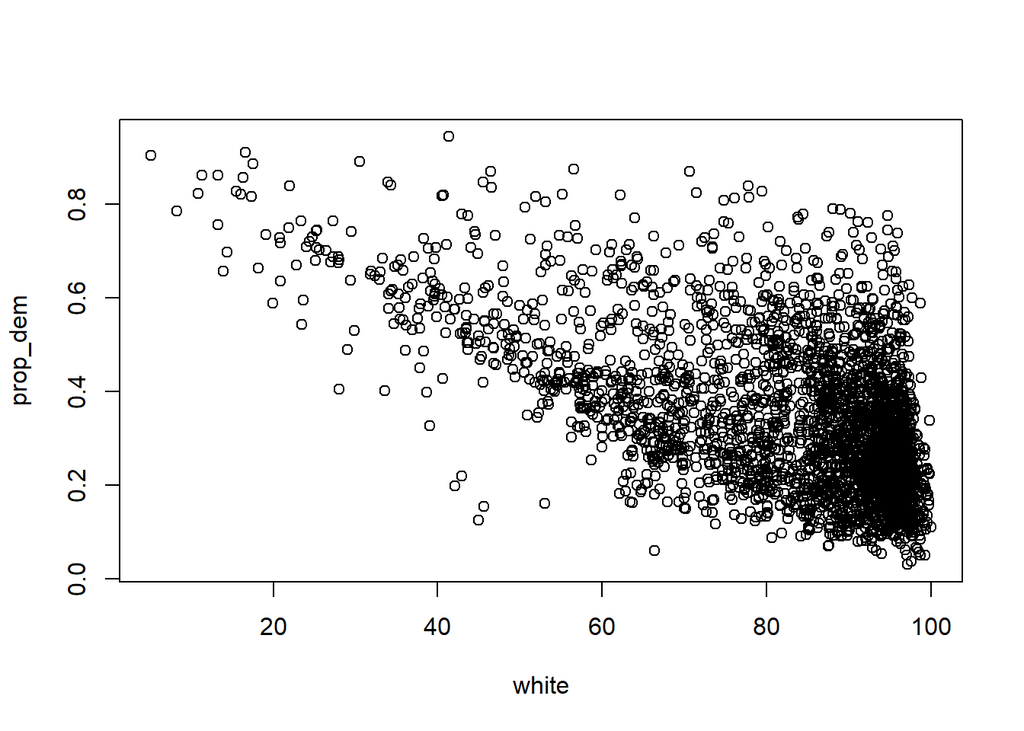

```r
plot(white, prop_dem)
```

### Question 5: Comparing Two Means: County Population

```r
mean(pop[blue])
```

```
## [1] 363744.4
```

```r
mean(pop[!blue])
```

```
## [1] 49831.46
```

```r
t.test(pop ~ blue)
```

```
##
##  Welch Two Sample t-test
##
## data:  pop by blue
## t = -10.065, df = 540.38, p-value < 2.2e-16
## alternative hypothesis: true difference in means between group FALSE and group TRUE is not equal to 0
## 95 percent confidence interval:
##  -375177.9 -252647.9
## sample estimates:
## mean in group FALSE  mean in group TRUE
##            49831.46           363744.37
```

The t-test shows that the null hypothesis that red and blue counties have the same average population is false. The extremely small p-value indicates that a difference of 0 between the averages of the two populations would be virtually impossible on repeated tests, and the confidence interval indicates that the true difference between the means is significantly large. The average population of blue counties in this sample is overwhelmingly higher than that of the red counties.

### Question 6: Comparing Two Means: Per Capita Incom

```r
t.test(per_capita_income ~ blue)
```

```
##
##  Welch Two Sample t-test
##
## data:  per_capita_income by blue
## t = -9.2901, df = 593.92, p-value < 2.2e-16
## alternative hypothesis: true difference in means between group FALSE and group TRUE is not equal to 0
## 95 percent confidence interval:
##  -5291.593 -3444.697
## sample estimates:
## mean in group FALSE  mean in group TRUE
##            27264.35            31632.49
```

This t-test rejects the null hypothesis that the per capita income in blue and red counties is the same. The p-value, similarly small to that in the previous t-test, shows that a difference of 0 between the average incomes is virtually impossible, and the confidence interval again shows that the true difference is significantly far from 0. The average per capita income in blue counties is more than $4,000 higher than that in red counties.